# More on PCGC Regression

Yu Xinyi

July, 2021

### 1. Different levels of polygenicity

Liability threshold model (infinitesimal):
$$l_i=g_i+e_i=x_i^T\beta+e_i=\sum_{j=1}^Mx_{ij}\beta_j+e_i \\
\beta_j\sim N(0,\frac{\sigma_g^2}{M}),\quad e_i\sim N(0,1-\sigma_g^2)$$
where $i=1,...,N$ represent individuals, $j=1,...,M$ represent SNPs. Assume individuals are mutually independent, and SNPs are i.i.d. In this model, all SNPs are causal. Observed phenotype $y_i=1$ if $l_i>t$, $y_i=0$ if $l_i\leq t$, where $t$ is the threshold determined by $t=\Phi^{-1}(1-K)$, $K$ is the population prevalence. $X\in\mathbb{R}^{N\times M}$ is genotype matrix with columns standardized to have mean 0 and variance 1. Also assume columns of $X$ are independent.

Liability threshold model (non-infinitesimal):
$$l_i=x_i^T\beta+e_i=\sum_{j\in\mathcal{C}}x_{ij}\beta_{j}+e_i$$
where $\mathcal{C}$ collects all $m_1$ causal SNPs (the rest $m_2\equiv M-m_1$ SNPs not in $\mathcal{C}$ have zero effect). For causal SNPs, $\beta_j\sim N(0,\frac{\sigma_g^2}{m_1})$. Other assumptions are unchanged.

PCGC regression:
$$\mathbb{E}[Z_{ii^{'}}|\mathcal{S}=1,\rho]=\frac{P(1-P)\phi{(t)}^2}{K^2(1-K)^2}\sigma_g^2 \rho$$
where $\rho$ is the genetic correlation between to different individuals in the study, calculated as:
$$\begin{align}
\rho&=Corr(X_i,X_{i^{'}})=\mathbb{E}[X_iX_{i^{'}}] \\
&=\frac{1}{M}\sum_{j=1}^M X_{ij}X_{i^{'}j} \quad (\rho\;\text{for infinitesimal model}) \\
\rho&=\frac{1}{M}\Big(\sum_{j\in\mathcal{C}}X_{ij}X_{i^{'}j}+\sum_{j\notin\mathcal{C}}X_{ij}X_{i^{'}j}\Big) \\
&=\frac{m_1}{M}\cdot\frac{1}{m_1}\sum_{j\in\mathcal{C}}X_{ij}X_{i^{'}j}+\frac{m_2}{M}\cdot\frac{1}{m_2}\sum_{j\notin\mathcal{C}}X_{ij}X_{i^{'}j} \\
&\equiv \frac{m_1}{M}\rho_1 + \frac{m_2}{M}\rho_2 \quad (\rho_1\;\text{for non-infinitesimal model})
\end{align}$$

If the phenotype has high level of polygenicity and we apply the infinitesimal model, where the genetic correlation $\rho$ serving as the regressor in PCGC regression is calculated using all the SNPs; if the phenotype has low level of polygenicity and the non-infinitesimal model is applied, the valid genetic correlation serving as the regressor in PCGC regression should be $\rho_1$ calculated using all the causal SNPs. However, we do not know which SNPs are causal, so we still use the infinitesimal model with genetic correlation $\rho=\frac{m_1}{M}\rho_1 + \frac{m_2}{M}\rho_2$. If genetic correlation $\rho_2$ in non-causal SNPs are similar to $\rho_1$, the resulting regression coefficient is expected not to be greatly affected.

PCGC regression function is implemented as follows:

```r
### pcgc regression without covariates
pcgc_reg = function(y, X, K, P){

  # y: standardized phenotype (mean 0, var 1)
  # X: standardized genotype matrix (column mean 0, var 1)
  # K: population prevalence
  # P: in-sample prevalence
  t = qnorm(1 - K)

  n = nrow(X)
  p = ncol(X)

  # phenotype correlations
  pheno_corr = outer(y, y) # n*n matrix, each entry is the phenotype correlation between two individuals

  # genotype correlations
  geno_corr = X%*%t(X)/p # n*n matrix, each entry is the genetic correlation between two individuals

  # multiply genotype correlations with the constant c
  phi_t = dnorm(t)
  c = P*(1 - P)*phi_t^2/(K^2*(1 - K)^2)
  geno_corr_c = c*geno_corr

  # regress phenotype correlations on genotype correlations
  pheno_corr_vec = pheno_corr[upper.tri(pheno_corr)]
  geno_corr_c_vec = geno_corr_c[upper.tri(geno_corr_c)]

  data = data.frame(y=pheno_corr_vec, X=geno_corr_c_vec)
  fit = lm(y~X, data=data)
  h2l = summary(fit)$coefficients[2,1] # liability scale heritability

  return(h2l)

}
```

In the first simulation, I set 3 different heritabilities: 0.2, 0.5, 0.8 and 6 different proportions of causal SNPs: 0.1%, 0.5%, 1%, 10%, 25%, 100%. All 10000 SNPs have MAFs generated from U[0.01, 0.5]. Total number of sample $n=4000$. Population prevalence $K=0.01$ and in-sample prevalence $P=0.3$. For each setting, simulation is replicated 20 times.

```r
# parameters
K = 0.01
P = 0.3
t = qnorm(1 - K)
p = 10000
n = 4000
# cases and control numbers
n_case = n*P
n_control = n*(1 - P)
# heritabilities
h2ls = c(0.2, 0.5, 0.8)
# proportions of causal SNPs
caus = c(0.001, 0.005, 0.01, 0.1, 0.25, 1)
# number of replication
nrep = 20
for(j in 1:length(caus)){
  ncau = caus[j]*p
  for(k in 1:length(h2ls)){
    h2l = h2ls[k]
    for(rep in 1:nrep){
      # mafs are from U[0.01, 0.5]
      mafs = runif(p, 0.01, 0.5)
      # first ncau snps are causal, the rest snps are non-causal
      beta = rep(0, p)
      # causal SNP effect sizes
      beta[1:ncau] = rnorm(ncau, 0, sqrt(h2l/ncau))
      # create individuals
      n1 = n0 = 0
      G1 = X1 = matrix(NA, n_case, p)
      G0 = X0 = matrix(NA, n_control, p)
      l1 = l0 = c()
      i = 0
      while(n1 < n_case | n0 < n_control){
        i = i + 1
        # generate a genotype
        g = rbinom(p, 2, mafs)
        # standarized the genotype
        x = (g - 2*mafs)/sqrt(2*mafs*(1 - mafs))
        # liability for this individual
        l = sum(x*beta) + rnorm(1, 0, sqrt(1-h2l))
        # phenotype
        if(l > t & n1 < n_case){
          n1 = n1 + 1
          G1[n1,] = g
          X1[n1,] = x
          l1[n1] = l
        }else{
          if(n0 < n_control){
            n0 = n0 + 1
            G0[n0,] = g
            X0[n0,] = x
            l0[n0] = l
          }
        }
      }
      G = rbind(G1, G0)
      X = rbind(X1, X0)
      l = c(l1, l0)
      y = c(rep(1, n_case), rep(0, n_control))
      y_std = (y - P)/sqrt(P*(1 - P))
    }
  }
}
```

Simulation results are shown below. Red boxes and blue boxes represent genetic correlation calculated by all SNPs and all causal SNPs, respectively. When the genetic structure is not too sparse (i.e expect for the setting when causal SNP proportion is 0.1%), PCGC regression with genetic correlation calculated by all SNPs or causal SNPs yields unbiased or moderately biased heritability estimates. When the genetic structure is very sparse (e.g only 0.1% SNPs are causal), heritability estimated by PCGC regression has large variance and is significantly biased when the true heritability is large ($h^2=0.8$ in the simulation).

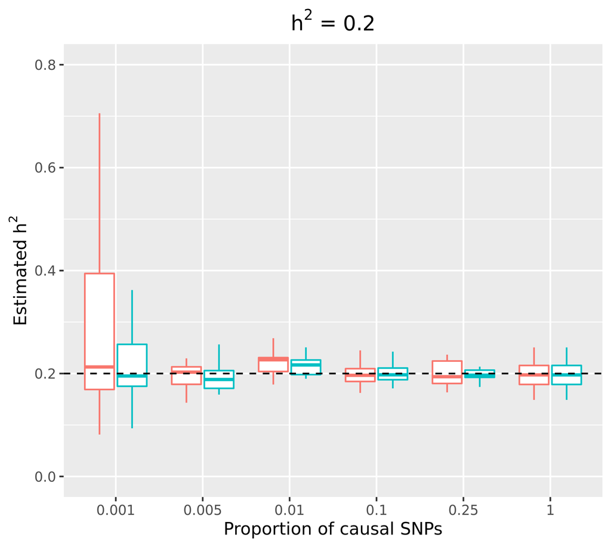

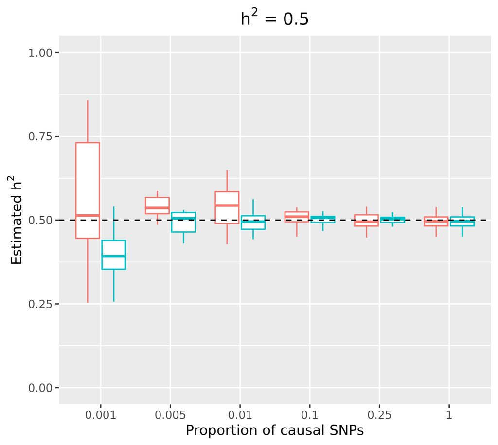

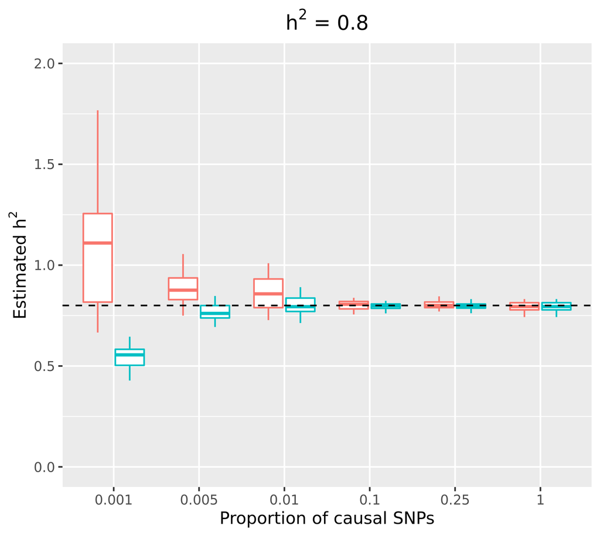

Polygenicity: uniform MAFs

In the second simulation, I force half of the causal SNPs to have low MAFs generated from U[0.01, 0.05] and the rest SNPs are still generated from U[0.01, 0.5]. All the other parameter settings follow from the first simulation.

```r
# half of causal snps are from U[0.01, 0.05]
mafs = runif(p, 0.01, 0.5)
mafs[1:(ncau/2)] = runif(ncau/2, 0.01, 0.05)
```

The results are shown below. When the MAF pattern of causal SNPs is significantly different from non-causal SNPs, genetic correlation calculated using all the SNPs are not very representative of that calculated using all the causal SNPs especially when the genetic structure is relatively sparse. In such cases, PCGC regression yields severely biased heritability estimates.

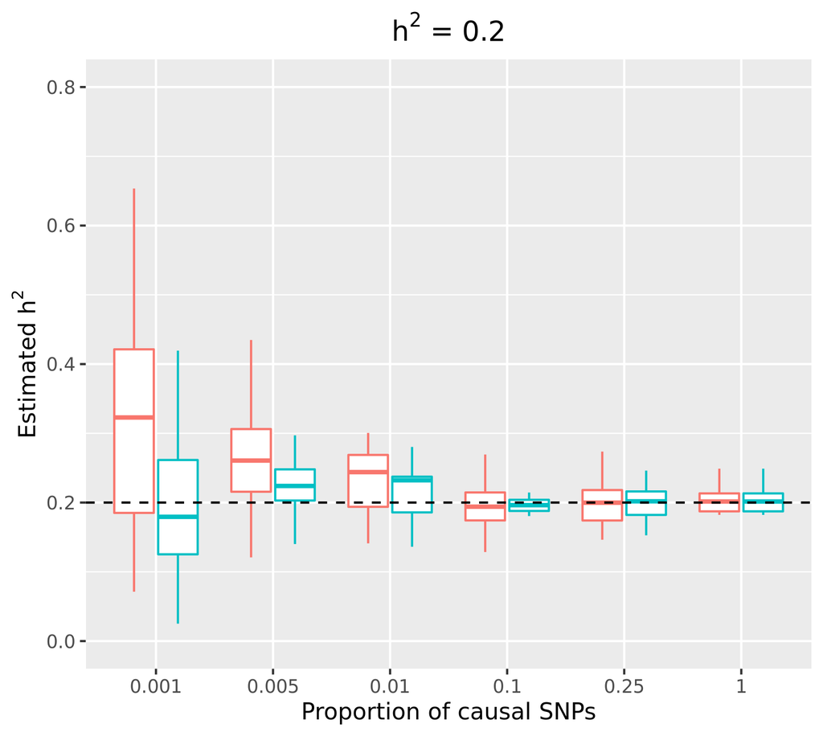

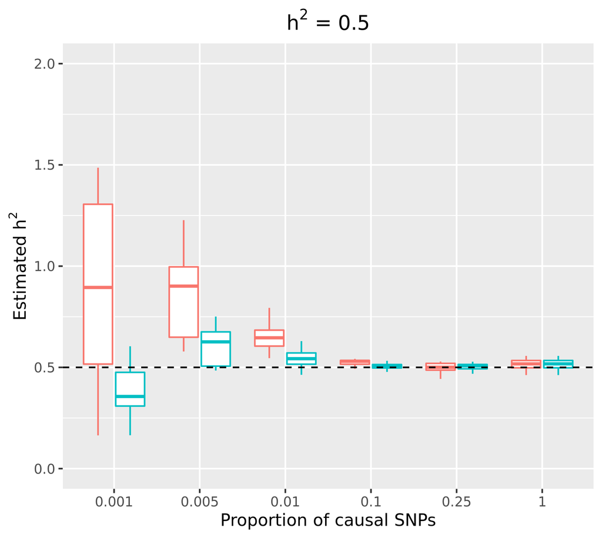

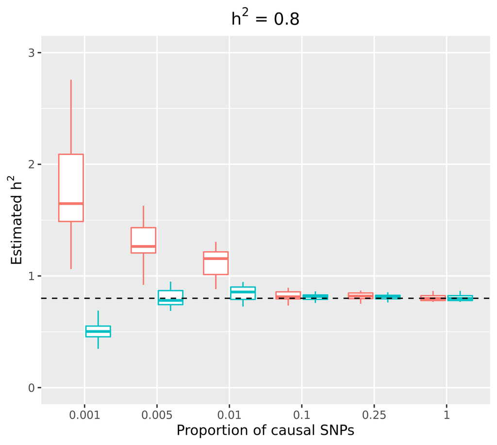

Polygenicity: causal SNPs with more low MAFs

### 2. Fixed effects

Liability threshold model:
$$\tilde{l}_i=z_i^T\alpha+l_i=z_i^T\alpha+g_i+e_i\\
g_i\sim N(0,\sigma_g^2)\\
e_i\sim N(0,1-\sigma_e^2)$$
Observed phenotype $y_i=1$ if $\tilde{l}_i>t$, $y_i=0$ if $\tilde{l}_i\leq t$, same $t$ as previous. Equivalently, we keep the definition of liability as $l_i=g_i+e_i$, then $y_i=1$ if $l_i>t_i$, $y_i=0$ if $l_i\leq t_i$, where $t_i=t-z_i^T\alpha$ is the individual-specific threshold (threshold conditional on the covariate $z_i$). This means: where individual $i$ is affected or unaffected is still determined by the sum of genetic effect $g_i$ and environmental effect $e_i$, with a specific threshold $t_i=t-z_i^T\alpha$. It follows with population-level parameters and individual-specific parameters:
$$\begin{align}
K&=\mathbb{P}(y_i=1;t)=1-\Phi^{-1}(t) \\
P&=\mathbb{P}(y_i=1|s_i=1;t) \\
K_i&=\mathbb{P}(y_i=1;t_i)=1-\Phi^{-1}(t_i) \\
P_i&=\mathbb{P}(y_i=1|s_i=1;t_i)
\end{align}$$

The presence of fixed effects increases the variance of the liability, so $\sigma_g^2$ is no longer equals to $h^2$. The heritability is defined as
$$h^2=\frac{\sigma_g^2}{\sigma_g^2+\sigma_e^2+\sigma_t^2}=\frac{\sigma_g^2}{1+\sigma_t^2}$$
where $\sigma_t^2$ is the variance of thresholds in the population. PCGC regression still estimates $\sigma_g^2$. Therefore, to get the estimation of heritability $h^2$ defined as above, we need to divide $\sigma_g^2$ by $1+\sigma_t$.

If the fixed effects are known, combining with known $K$ and $P$, we can calculate individual specific parameters $t_i$, $P_i$, $K_i$ and then the individual-specific adjusting constant $c_i$ for genetic component $g_i$:
$$c_i=\frac{1-P_i\cdot \frac{P-K}{P(1-K)}}{\sqrt{(P_i(1-P_i))}(K_i+(1-K_i)\frac{K(1-P)}{P(1-K)})}$$

If the fixed effects are unknown, we can use logistic regression to get a consistent estimator of $P_i$: $\hat{P}_i$ (mentioned in PCGC supplementary: using a logistic regression to estimate fixed effects from ascertained data yields consistent estimators of these effects in the population, and the ascertainment only biases the intercept). Then use the following relationship to obtain an estimate of $K_i$:
$$K_i=\frac{\frac{K(1-P)}{P(1-K)}P_i}{1+\frac{K(1-P)}{P(1-K)}P_i-P_i}$$
which is used to estimate the threshold:
$$\hat{t}_i=\Phi^{-1}(1-\hat{K}_i)$$
These estimated individual-specific parameters are used in PCGC regression with fixed effects. After obtaining the estimate $\hat{\sigma}_g^2$, to get an estimate of heritability, we also need to estimate $\sigma_t^2$.
By the law of total variance:
$$\begin{align}
\sigma_t^2&=Var(\mathbb{E}(t\,|\,y))+\mathbb{E}(Var(t\,|\,y)) \\
\mathbb{E}(Var(t\,|\,y))&=K(\mathbb{E}(t\,|\,y=1)-t)^2+(1-K)(\mathbb{E}(t\,|\,y=0)-t)^2 \\
&=K(1-K)(\mathbb{E}(t\,|\,y=1)-\mathbb{E}(t\,|\,y=0))^2 \\
Var(\mathbb{E}(t\,|\,y))&=KVar(t\,|\,y=1)+(1-K)Var(t\,|\,y=0)
\end{align}$$
Once we condition on a specific phenotype, both the expected and variance of $t$ can be estimated from the data. Specifically, we use the estimated thresholds $\hat{t}_i$ to estimate the expected value and variance of the thresholds for cases and controls, and plug the estimates into the equation above to obtain $\hat{\sigma_t}^2$.

PCGC regression with covariates is implemented as follows.

```r
### calculate individual-specific constants, and standardize phenotype
transformPheno = function(phen, fe, K, alpha=NULL){

  # phen: n-vector phenotype
  # fe: n*c matrix fixed effects
  # K: population prevalence
  # alpha: fixed effects

  # estimated sample prevalence
  P = mean(phen,na.rm=T)
  const1 = K/(1 - K)*(1 - P)/P
  const2 = (P - K)/(P*(1 - K))

  # if fixed effects are unknown, fit logistic regression
  if(is.null(alpha)){
    model = glm(phen ~ fe , family="binomial")

    Pi = model$fitted
    Ki = const1*Pi/(1 + const1*Pi - Pi)

    y_std = (y - P)/sqrt(P*(1 - P))
    ci = dnorm(ti)*(1 - Pi*const2)/(sqrt(Pi*(1 - Pi))*(Ki + (1 - Ki)*const1))

    # compute the population-wise variance of the thresholds using the law of total-variance
    var.cases = var(ti[phen==1], na.rm=T)
    var.controls = var(ti[phen==0], na.rm=T)
    mean.cases = mean(ti[phen==1], na.rm=T)
    mean.controls = mean(ti[phen==0], na.rm=T)
    total.var = K*var.cases + (1-K)*var.controls + K*(1-K)*(mean.cases - mean.controls)^2

    # returns: standardized phenotype, constants c_i, variance of thresholds
    ret = list(phen=y_std, multiplier=ci, totalvar=total.var)
    return(ret)

  }else{
    t = qnorm(1 - K)
    ti = t - drop(matrix(Z)%*%alpha)
    Ki = 1 - pnorm(ti)
    Pi = Ki/(Ki + const1*(1 - Ki))

    y_std = (y - P)/sqrt(P*(1 - P))
    ci = dnorm(ti)*(1 - Pi*const2)/(sqrt(Pi*(1 - Pi))*(Ki + (1 - Ki)*const1))
    t_var = var(ti)

    ret = list(phen=y_std, multiplier=ci, totalvar=t_var)
    return(ret)
  }

}

### pcgc regression with covariates
pcgc_reg_covar = function(y, X, c, t_var){

  # y: standardized phenotype (mean 0, var 1)
  # X: standardized genotype matrix (column mean 0, var 1)
  # c: individual-specific adjusting constants for genetic components
  # t_var: variance of thresholds

  t = qnorm(1 - K)

  n = nrow(X)
  p = ncol(X)

  # phenotype correlations
  pheno_corr = outer(y, y) # n*n matrix, each entry is the phenotype correlation between two individuals

  # genotype correlations
  geno_corr = X%*%t(X)/p # n*n matrix, each entry is the genetic correlation between two individuals

  # multiply genotype correlations with the constant c
  c_mat = outer(c, c)
  c_vec = c_mat[upper.tri(c_mat)]

  # regress phenotype correlations on genotype correlations
  pheno_corr_vec = pheno_corr[upper.tri(pheno_corr)]
  geno_corr_c_vec = c_vec*geno_corr[upper.tri(geno_corr)]

  data = data.frame(y=pheno_corr_vec, X=geno_corr_c_vec)
  fit = lm(y~X, data=data)
  sig2g = summary(fit)$coefficients[2,1] # sigma_g^2

  # liability scale heritability
  h2l = sig2g/(1 + t_var)

  return(list(sig2g=sig2g, h2l=h2l))

}
```

I try to replicate the simulation with normally distributed fixed effect in PCGC supplementary Section 5.6. Liabilities are generated by:
$$\tilde{l}_i=z_i^T\alpha+g_i+e_i$$
with $z_i\sim N(0,1)$, so the overall variance of $\tilde{l}_i$ is $1+\alpha^2$. The heritability is set to 0.5, so $\sigma_g^2=\frac{1}{2}(1+\alpha^2)$. Other parameters: $K=0.01$, $P=0.3$, $n=4,000$, $p=10,000$. $\alpha^2$ is set to be 0.01, 0.05, 0.1, 0.25.

```r
# parameters
K = 0.01
P = 0.3
h2l = 0.5
p = 10000
n = 4000
# case and control numbers
n_case = n*P
n_control = n*(1 - P)
# square of fixed effect sizes
alpha2s = c(0.01, 0.05, 0.1, 0.25)
# mafs
mafs = runif(p, 0.05, 0.5)
# number of replication
nrep = 20
for(alpha2 in alpha2s){
  # true sigma_g^2
  sig2g = h2l*(1 + alpha2)
  # fixed effect
  alpha = sqrt(alpha2)
  # threshold when z=0
  t = qnorm(1-K)
  for(rep in 1:nrep){
    beta = rnorm(p, 0, sqrt(sig2g/p)) # SNP effect sizes
    ## generate data
    n1 = n0 = 0
    G1 = X1 = matrix(NA, n_case, p)
    G0 = X0 = matrix(NA, n_control, p)
    l1 = l0 = c()
    Z1 = Z0 = c()
    i = 0
    while(n1 < n_case | n0 < n_control){
      # generate a genotype
      g = rbinom(p, 2, mafs)
      # standarized the genotype
      x = (g - 2*mafs)/sqrt(2*mafs*(1 - mafs))
      # generate a quantitative covariate value
      z = rnorm(1)
      # liability for this individual
      l = sum(x*beta) + rnorm(1, 0, sqrt(1-sig2g))
      # phenotype
      if(l > (t-z*alpha) & n1 < n_case){
        i = i + 1
        n1 = n1 + 1
        G1[n1,] = g
        X1[n1,] = x
        l1[n1] = l
        Z1[n1] = z
      }else{
        if(n0 < n_control){
          i = i + 1
          n0 = n0 + 1
          G0[n0,] = g
          X0[n0,] = x
          l0[n0] = l
          Z0[n0] = z
        }
      }
    }
    G = rbind(G1, G0)
    X = rbind(X1, X0)
    l = c(l1, l0)
    Z = c(Z1, Z0)
    y = c(rep(1, n_case), rep(0, n_control))
    y_std = (y - P)/sqrt(P*(1 - P))
  }
}
```

The simulation results displayed in the supplementary confirmed the unbiasedness of PCGC estimates in the presence of regression. While my simulation results show downward biases of both $\sigma_g^2$ and $h^2_l$. I suspect the biases are caused by different simulation procedures.

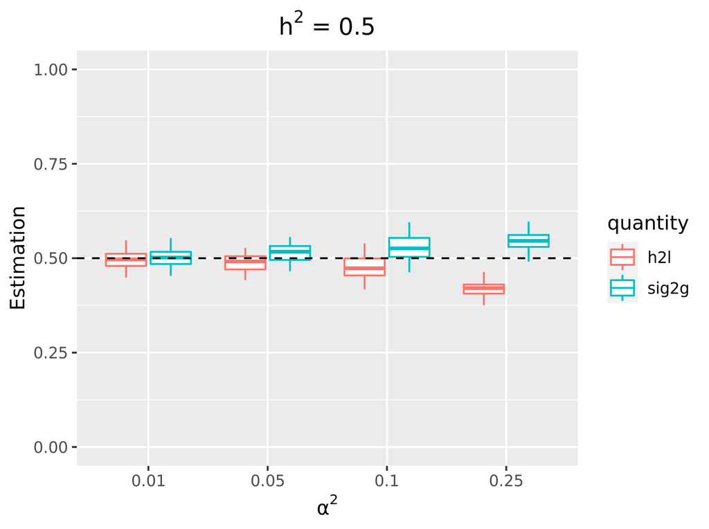

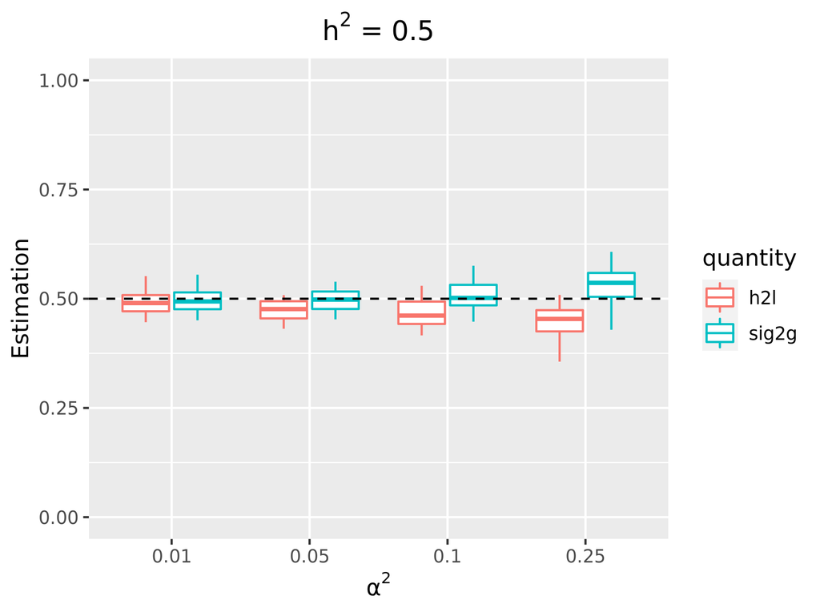

PCGC with Covariates. Left: known fixed effects. Right: fixed effects estimated by logistic regression